# Pipeline <> App Simulações - EDA

Felipe Daiha Alves

2023-02-07

# **Disclaimer**:

Etapas para elaboração do relatório de análise referente ao processo de **Simulações no App** para avaliação de inatividade de clientes.

# **Objetivo**:

Este relatório contém as etapas de **análise exploratória de dados** para determinação de variáveis relevantes para o futuro processo de modelagem de algoritmos.  
Para avaliação, segue os dados:

## **1 - Carregando dados**

Etapa inicial de processamento de dados. Nele, iremos carregar a base de simulações por **cliente/dia útil** disponibilizado via *AWS S3*. Se ocorrer qualquer problema, foi também criado uma cópia local para importação dos dados.

```
WARN  [2023-02-07 14:03:59] Key: app_simulation/cleaned/app_simulation_infos.csv
```

```
INFO  [2023-02-07 14:04:01] CSV file loaded from S3 Bucket 'github-datasets'
Rows: 15,791
Columns: 20
$ id                                            <chr> "WZVSA6811", "WZVSA6811"…
$ date                                          <chr> "2022-10-07", "2022-10-1…
$ rolling_sum_login_on_app                      <dbl> 0.00, 0.00, 0.00, 0.00, …
$ rolling_sum_simulations                       <dbl> 0.00, 0.00, 0.33, 0.75, …
$ rolling_avg_income                            <dbl> 0.00, 0.00, 10000.00, 73…
$ rolling_avg_loan_amount                       <dbl> 0.00, 0.00, 17284.00, 15…
$ rolling_sum_rejected_on_first_analysis        <dbl> 0.00, 0.00, 0.00, 0.50, …
$ rolling_sum_approved_on_first_analysis        <dbl> 0.00, 0.00, 0.00, 0.00, …
$ rolling_sum_sent_to_second_analysis           <dbl> 0.00, 0.00, 0.33, 0.25, …
$ rolling_sum_approved_on_second_analysis       <dbl> 0.00, 0.00, 0.33, 0.25, …
$ rolling_sum_rejected_on_second_analysis       <dbl> 0.00, 0.00, 0.00, 0.00, …
$ rolling_mean_hours_simulation_second_analysis <dbl> -1.00, -1.00, 1.00, 1.00…
$ rolling_sum_sent_to_first_step_after_analysis <dbl> 0.00, 0.00, 0.33, 0.25, …
$ rolling_mean_days_first_analysis_first_step   <dbl> -1, -1, 3, 3, 3, 3, 3, 3…
$ rolling_sum_second_step                       <dbl> 0.00, 0.00, 0.00, 0.00, …
$ rolling_mean_days_first_step_second_step      <dbl> -1, -1, -1, -1, -1, -1, …
$ rolling_sum_final_step                        <dbl> 0.00, 0.00, 0.00, 0.00, …
$ rolling_mean_days_second_step_final_step      <dbl> -1, -1, -1, -1, -1, -1, …
$ rolling_sum_canceled_simulations              <dbl> 0.00, 0.00, 0.00, 0.00, …
$ will_simulate_d1                              <lgl> FALSE, TRUE, TRUE, FALSE…
```

## **2 - Análise Exploratória de Dados**

Na fase de *EDA*, iremos nos concentrar em gerar avaliações gráficas e descritivas em relação aos *target* **will_simulate_d1**.

1. **Histórico Geral**  
   Inicialmente, será analisado relações históricas entre as variáveis, de forma a compreender na totalidade o comportamento das features criadas.

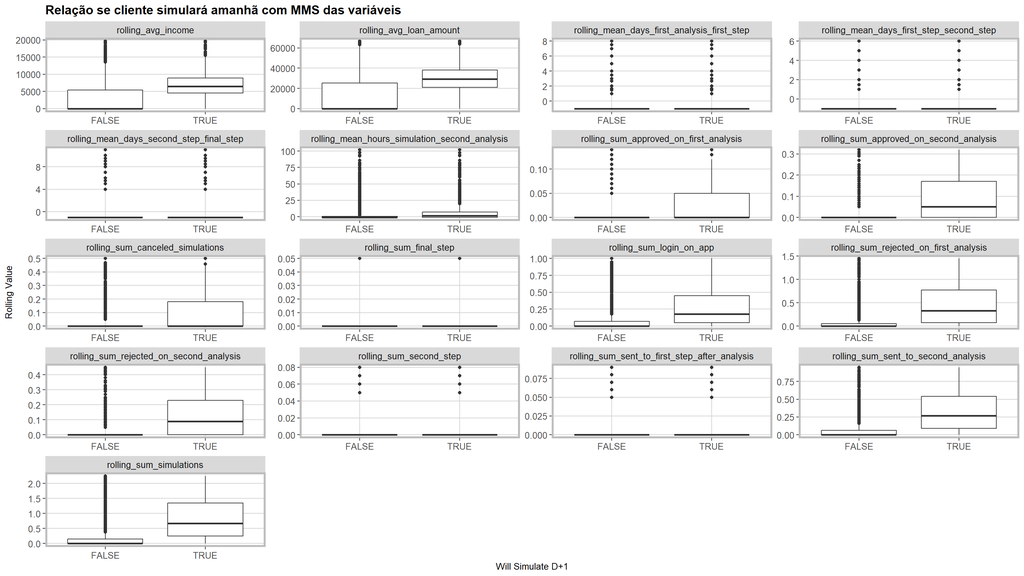

```
INFO  [2023-02-07 14:04:05] Plot vertical boxplot analysis succesfully done!
```

**Comments:** Essa primeira visão busca compreender as variáveis mais relevantes em nível histórico no seu estado mais bruto, sem transformação nos dados, para diferenciação do target. São elas:

- *rolling_avg_income*
- *rolling_avg_loan_amount*
- *rolling_sum_approved_on_second_analysis*
- *rolling_sum_canceled_simulations*
- *rolling_sum_login_on_app*
- *rolling_sum_rejected_on_first_analysis*
- *rolling_sum_simulations*
- *rolling_sum_rejected_on_second_analysis*

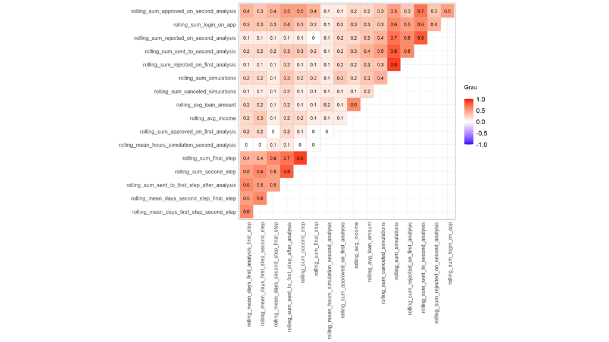

```
INFO  [2023-02-07 14:04:09] Corrplot between rolling features succesfully builded!
```

**Comments:** Nesse outra visão, buscamos entender quais variáveis são correlacionadas entre si, para evitar casos de multicolinearidade. A partir das duas análises em conjunto, podemos partir das seguintes premissas:

- **Qualidade dos Clientes** (*rolling_avg_income*) - A primeira premissa parte do princípio que clientes mais bem qualificados (alta renda; simulando altos empréstimos) são mais propícios a **aprovação de simulações** e, consequentemente, **melhores condições do financiamento**.
- **Aprovado em Segunda Análise** (*rolling_sum_approved_on_second_analysis*) - Outra premissa é referente à **aprovação de clientes em segunda instância**. Quando a simulação é reavaliada, há demasiada **interação entre a instituição financeira e o cliente**, no sentido de mensagens trocadas, documentos a serem anexados/esclarecidos, etc. Isso reforça a relação entre as partes. Ao ver que suas simulações de crédito vão sendo aprovadas, há maior procura pela plataforma.
- **Interação com a Plataforma** (*rolling_sum_login_on_app*) - Por último, e mais intuitivo. Quanto mais **logins** na plataforma, maior a quantidade de cleintes simulando.

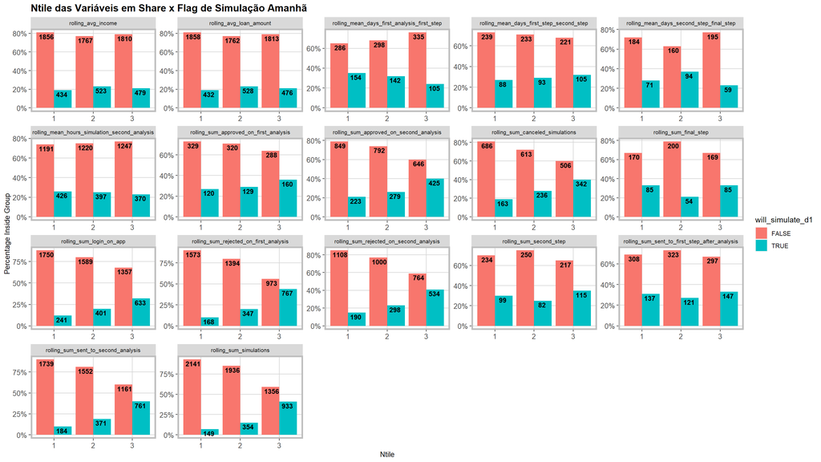

```
INFO  [2023-02-07 14:04:12] Ntile plot succesfully builded!
```

**Comments:** Quando rankeamos/categorizamos nossas variáveis numéricas, podemos encontrar padrões com mais clareza em features que em primeira análise pareciam fracas para discriminação da variável resposta. São exemplo delas e sua explicação:

- *rolling_mean_days_first_analysis_first_step* - Quanto maior o tempo entre as etapas, **maior a tendência ao churn** do cliente Isso é lógico, visto que torna-se um processo **burocrático**, enquanto outras instituições de financiamento apresentam seu produto mais acelerado na tomada de decisão das simulações.
2. **Efeito Temporal**  
   Agora, será estudada o comportamento das variáveis frente ao tempo, sobretudo se há variações/estabilidade de padrões.

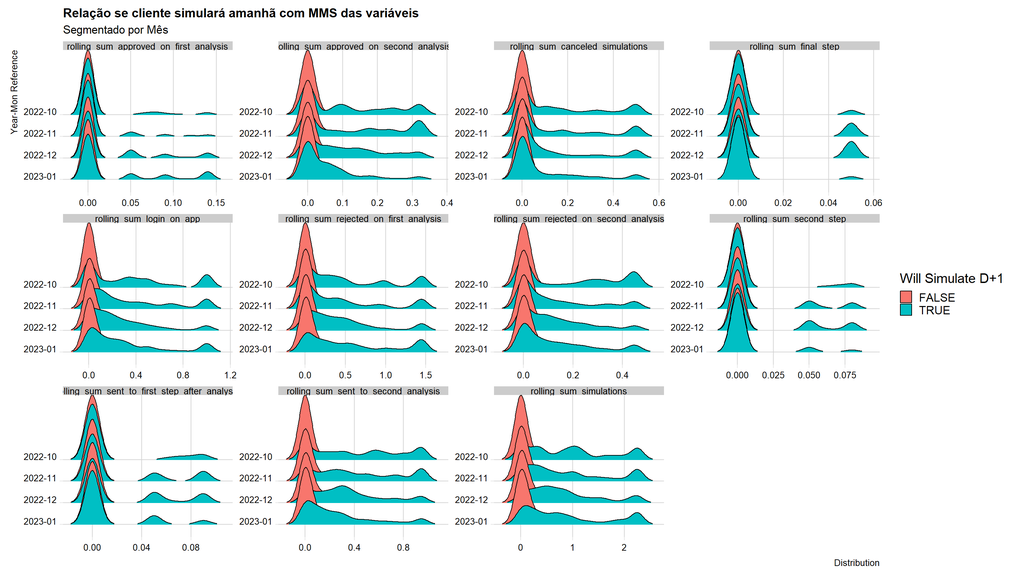

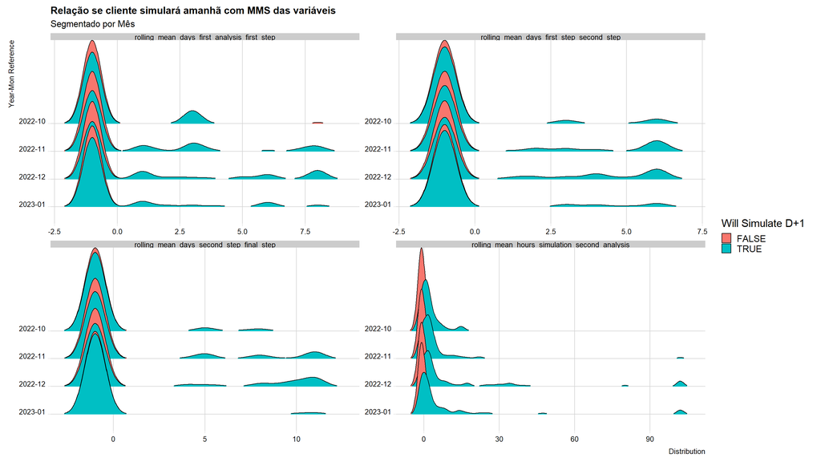

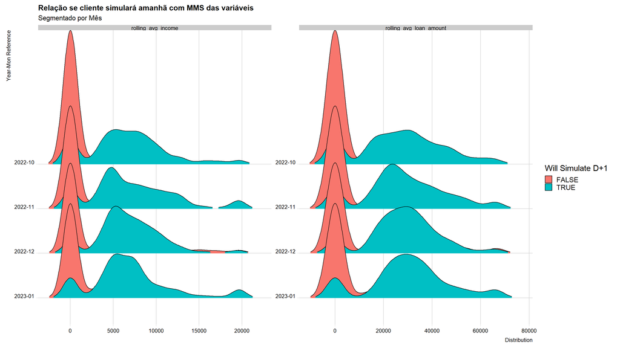

```
INFO  [2023-02-07 14:04:28] Plot distribution over months succesfully builded!
```

**Comments:** Como os dados são influenciados pelo tempo, precisamos compreender os **componentes** que afetam a relação das features com os dias corridos.  
Dentre as variáveis destacadas em análises prévias, **não há fortes evidências** de *shift* temporal nas features. De uma forma geral, as distribuições em relação ao target são **consideravelmente estáveis** no passar dos meses, mostrando um perfil de público similar no decorrer do tempo.  
Para validarmos, será feito o estudo das distribuições pelo *Teste de Kolmogorov-Smirnov*.

**Teste de KS - Relação entre Último Mês e Restante dos Dados**

|  | stat_value | feature |
| --- | --- | --- |
| 1 | 0.1060 | rolling_sum_approved_on_second_analysis |
| 2 | 0.0868 | rolling_sum_sent_to_second_analysis |
| 3 | 0.0750 | rolling_sum_rejected_on_first_analysis |
| 4 | 0.0664 | rolling_avg_loan_amount |
| 5 | 0.0619 | rolling_mean_hours_simulation_second_analysis |
| 6 | 0.0507 | rolling_sum_final_step |
| 7 | 0.0507 | rolling_mean_days_second_step_final_step |
| 8 | 0.0435 | rolling_sum_canceled_simulations |
| 9 | 0.0427 | rolling_sum_second_step |
| 10 | 0.0422 | rolling_avg_income |
| 11 | 0.0408 | rolling_mean_days_first_step_second_step |
| 12 | 0.0406 | rolling_sum_approved_on_first_analysis |
| 13 | 0.0385 | rolling_sum_sent_to_first_step_after_analysis |
| 14 | 0.0377 | rolling_sum_simulations |
| 15 | 0.0308 | rolling_sum_login_on_app |
| 16 | 0.0273 | rolling_mean_days_first_analysis_first_step |
| 17 | 0.0259 | rolling_sum_rejected_on_second_analysis |

INFO [2023-02-07 14:04:35] Dataframe with KS test succesfully rendered!  
**Comments:** O teste de KS nos mostra que os dados de treino e teste **não apresentam significativas diferenciações nas distribuições de probabilidade**, indicando que o fator tempo não mostra-se de grande influência para *shift* das variáveis.  
Portanto, este estudo direcionado consegue inferir as seguintes variáveis como **discriminantes** para determinação do *target* escolhido:

- *rolling_sum_login_on_app* - Bruto
- *rolling_avg_loan_amount* - Bruto ou Binário
- *rolling_sum_simulations* - Bruto
- *rolling_sum_approved_on_second_analysis* - Bruto
- *rolling_mean_days_first_analysis_first_step* - Convertido para Ntile (n=3)